# Praca domowa nr 5

Marceli Korbin

18 maja 2020

## Wstęp

Na zbiorze danych *clustering.csv* przetestujemy dwie metody klasteryzacji. W zbiorze znajdują się dwie kolumny liczb z zakresu od około -100 do około 100, które można przedstawić punktami na układzie współrzędnych.

```r
dane <- read.csv("../../clustering.csv", header=F)
colnames(dane) <- c("x", "y")
head(dane)
```

```
##           x          y
## 1  41.78891  52.220182
## 2 -96.58652  90.957033
## 3 -54.14359 -99.153377
## 4  19.92923 -45.859779
## 5 -82.94108  84.099186
## 6  13.39000  -4.016202
```

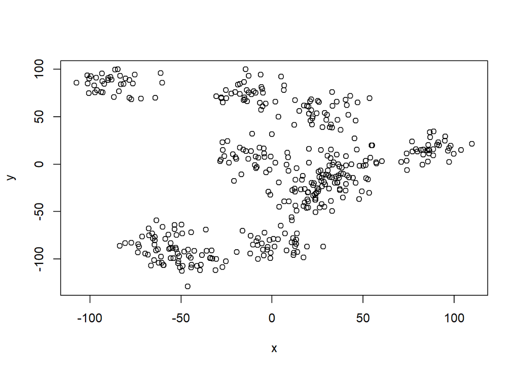

```r
plot(dane)
```

## Metoda pierwsza: k-średnie

Oczywiście na początku niekoniecznie wiadomo, na ile klastrów należy podzielić te punkty. Przed każdą z metod wykorzystam zatem funkcję *fviz_nbclust* z pakietu *factoextra*, która poprzez wykresy wskaże odpowiednią liczbę skupień.

Do tej części wykorzystuję metodę “silhouette”.

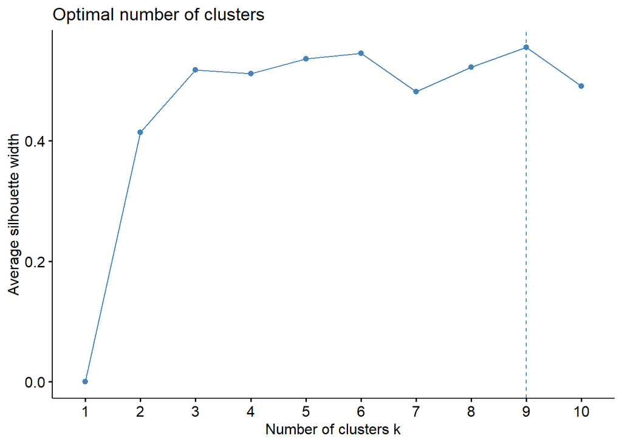

```r
fviz_nbclust(dane, kmeans, method="silhouette")
```

Już na samym wykresie wyraźnie wskazane jest 9 klastrów. Do algorytmu biorę funkcję *kmeans* z pakietu *stats*.

```r
klastry1 <- kmeans(dane, 9)
# punkty skupień:
klastry1$centers
```

```
##            x          y
## 1 -53.710454 -91.395667
## 2  38.952354  -4.228012
## 3  87.069829  15.540660
## 4   2.542381 -84.442649
## 5 -11.095926   7.492615
## 6  28.351304  55.366251
## 7  21.329882 -32.554976
## 8 -12.693934  75.574306
## 9 -87.073243  84.919179
```

```r
# rozmiary skupień:
klastry1$size
```

```
## [1] 72 56 36 38 36 37 54 35 36
```

Wyżej wypisałem centralne punkty klastrów i rozmiary wytworzonych grup. Reprezentacja graficzna z rombami w środkach skupień:

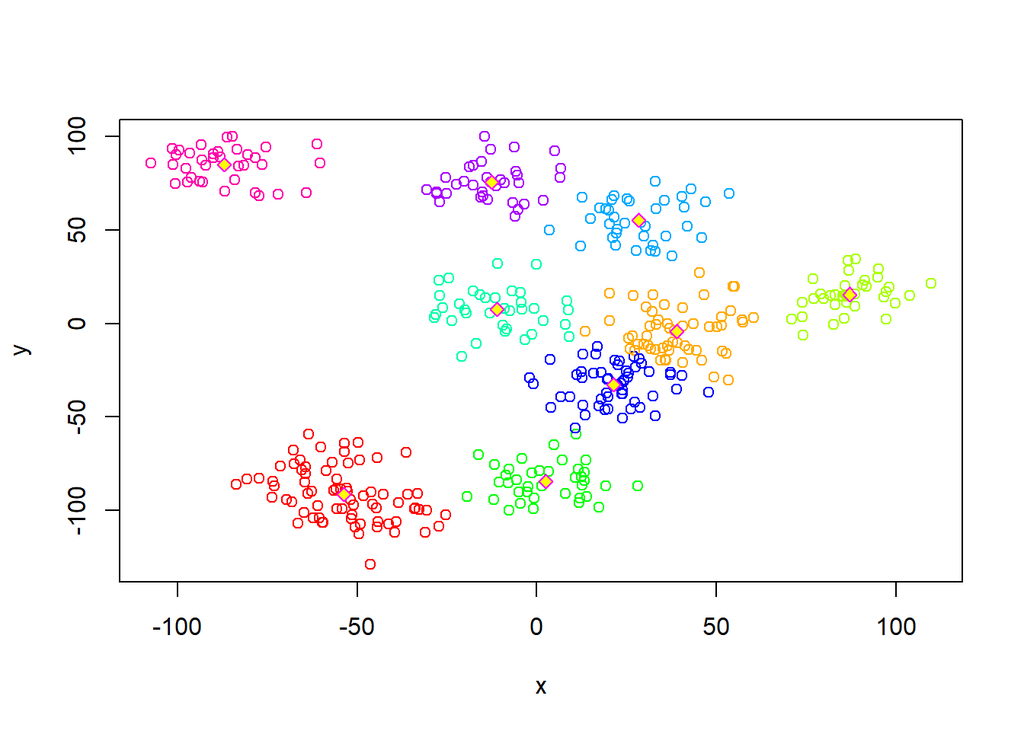

```r
plot(dane, col=rainbow(9)[klastry1$cluster])
points(klastry1$centers, pch=23, col="magenta", bg="yellow")
```

## Metoda druga: hierarchiczna

Przed klasteryzacją wyznaczę liczbę klastrów metodą łokcia.

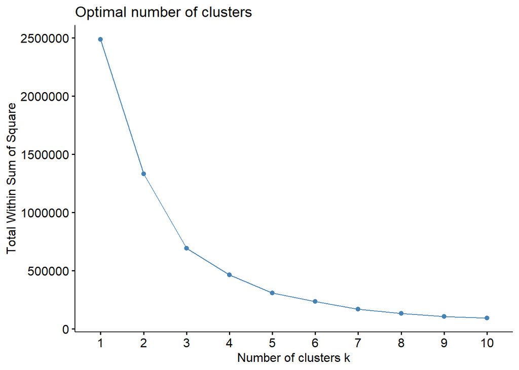

```r
fviz_nbclust(dane, hcut, method="wss")
```

Jako optymalną liczbę klastrów należy wybrać tę, dla której na wykresie powyżej zaszło największe zgięcie. Mogło ono mieć miejsce dla *k* z zakresu od 2 do 5, ale nie potrafię tego jednoznacznie określić na oko. Wyznaczam to zatem bardziej matematycznie.

Dla każdego punktu *k* sprawdzam różnicę między metryką (opisaną na osi y wykresu wyżej) dla *k* a tą dla *k*+1. Powiększam następnie metrykę dla *k* o tę różnicę i sprawdzam, ile procent metryki dla *k*-1 stanowi obliczona liczba. Im bliżej 100%, tym mniejsze zgięcie. Wartość powyżej 100% oznacza zgięcie w przeciwną stronę niż poszukiwana. Mniejszy odsetek oznacza z kolei, że poprzednia metryka była bardzo wysoka i między nią a metryką dla punktu *k* nastąpił duży zjazd.

```r
elbow <- fviz_nbclust(dane, hcut, method="wss")
for (k in 2:9) {
  print(paste(k, ": ", sep=""), quote=F)
  print((elbow$data$y[k]*2-elbow$data$y[k+1])/elbow$data$y[k-1])
}
```

```
## [1] 2:
## [1] 0.7916642
## [1] 3:
## [1] 0.6910186
## [1] 4:
## [1] 0.8918837
## [1] 5:
## [1] 0.8332076
## [1] 6:
## [1] 0.9614942
## [1] 7:
## [1] 0.8878128
## [1] 8:
## [1] 0.9391386
## [1] 9:
## [1] 0.8869775
```

Najniższy procent wyszedł dla *k*=3 i to tę wartość ustalamy jako liczbę klastrów. Tym razem używam *hcut*, z *factoextra*.

```r
klastry2 <- hcut(dane, 3)
# rozmiary skupień:
klastry2$size
```

```
## [1] 108 108 184
```

W tym wypadku informacja o punktach środkowych klastrów jest niedostępna. Reprezentacja graficzna:

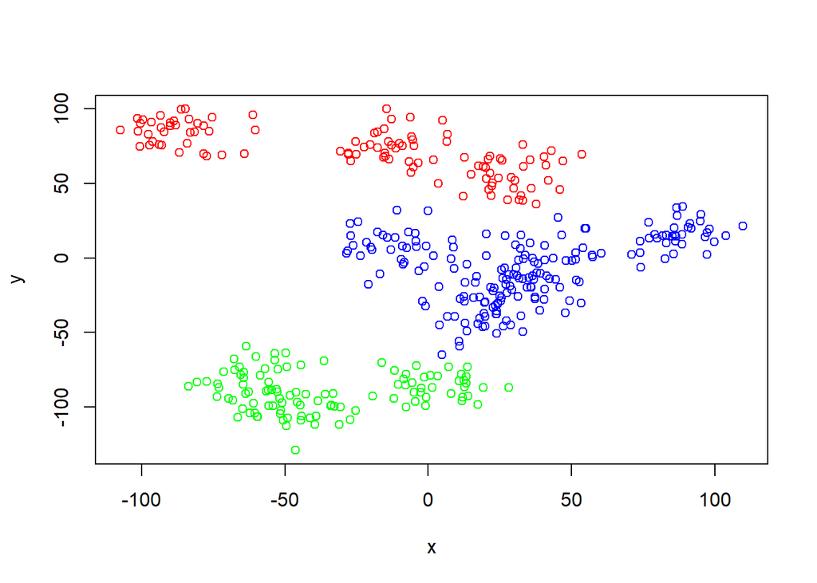

```r
plot(dane, col=rainbow(3)[klastry2$cluster])
```

Z obu stylów klastrowania preferuję metodę k-średnich. Druga łączyła w grupy punkty dalsze od siebie…

## Oświadczenie

*Oświadczam, że niniejsza praca stanowiąca podstawę do uznania osiągnięcia efektów uczenia się z przedmiotu **Wstęp do uczenia maszynowego** została wykonana przeze mnie samodzielnie.*